# Analysis on Hotel Booking and Cancellation

Name: Lei Yang

## Introduction

### Problem Descriptions

The goal of the project is to make the hospitality business more competitive by using data to help make decisions. Li (2018) says that companies that rely on data are much more likely to get better at making decisions. Maximizing revenue and guest happiness are the most important things in the hotel business. This study uses information about hotel reservations to get useful insights and find growth possibilities. We'll look at booking patterns, guest tastes, and cancellation rates to see if there are any patterns across all types of hotels. A predictive model will also be made to predict cancellations of reservations, which will help hotels improve the way they handle reservations. The end goal is to improve guest experiences and streamline operations by incorporating advanced analytics and machine learning into Revenue Management Systems (RMS). This is because big data has changed the industry so much (Provost, 2013). The goal of this method is not only to guess how customers will act in the future, but also to make the business better and make customers happier.

### Motivation

These days, making decisions based on data is very important for businesses to succeed. The hotel industry is at the front of a big change. Big data and advanced analytics technologies have changed the way hotels work by giving them deep insights into how customers behave, how markets change, and how to run their businesses more efficiently. As the battle gets tougher, it becomes very important to be able to use data to not only understand but also predict what customers want and need. The reason for this study is that these changes and the chances they create are becoming more clear. The goal of this study is to find patterns, trends, and correlations in hotel booking data that could help with making smart decisions, making customers happier, and bringing in more money. Basically, it tries to connect the old ways of managing hotels with the new ways of using big data analytics. This way, managers can find their way through the complicated world of business today.

## Datasets Description

This data was obtained from a comprehensive collection of hotel bookings, spanning across three years from [Kaggle](https://www.kaggle.com/datasets/hnytfo/hotel-booking-demand-by-year), Those datasets showcast the intricate dynamics of room demand for two distinct types of hotels.This information talks about datasets that encompass detailed records on room reservations for a "City Hotel" located in the bustling city of Lisbon, and a "Resort Hotel" situated in the serene vacation destination of the Algarve. The datasets meticulously record various aspects of hotel bookings over the years 2015, 2016, and 2017, including but not limited to the date the reservation was made, the demographic details of the guests (number of adults, children, and/or babies), the duration of their stay (both weekend and weekday nights), and the requirement for car parking spaces.

The first place the data came from was Hotel Booking Demand Datasets (Antonio, 2019). This dataset includes all reservations for trips that are set to happen between July 1, 2015, and August 31, 2017. It includes both confirmed and canceled appointments. The variables are described as follows:

- hotel: H1 = Resort Hotel / H2 = City Hotel
- is_canceled: Booking was canceled (1) or not (0)
- lead_time: Days between the booking entry date and the arrival date
- arrival_date_year: Arrival date's year
- arrival_date_month: Arrival date's month
- arrival_date_week_number: Week number of the year for the arrival date
- arrival_date_day_of_month: Day of the arrival date
- stays_in_weekend_nights: Number of weekend nights guest stayed
- stays_in_week_nights: Number of weeknights guest stayed
- adults: Number of adults
- children: Number of children
- babies: Number of babies
- meal: Meal type
- country: Country of origin
- market_segment: Market segment designation
- distribution_channel: Booking distribution channel
- is_repeated_guest: Repeated guest (1) or not (0)
- previous_cancellations: Previous bookings that were canceled count
- previous_bookings_not_canceled: Previous bookings not canceled count
- reserved_room_type: Room type code reserved
- assigned_room_type: Room type code assigned
- booking_changes: Number of booking changes
- deposit_type: No Deposit, Non-Refund, Refundable
- agent: ID of the travel agency
- company: ID of the company
- days_in_waiting_list: Days that booking was on the waiting list
- customer_type: Contract, Group, Transient, Transient-party
- adr: Average Daily Rate
- required_car_parking_spaces: Car parking spaces requested by the customer
- total_of_special_requests: Special requests made by the customer
- reservation_status: Canceled, Check-Out, No-Show Status
- reservation_status_date: Date of the last status update

There are 32 columns and 119210 rows in the data. Since it comes from real hotel data, any information that could be used to find out who the customer or hotel is has been taken out.

## Business Questions

1. **Analysis of Booking and Cancellation Trends:** What are the volume and patterns of bookings and cancellations across different times and conditions? This question seeks to understand the dynamics of hotel bookings, including seasonal variations, the impact of external events, and the effectiveness of marketing and pricing strategies in influencing booking behaviors.
2. **Monthly Booking Distribution:** How do booking rates vary by month, and what can this tell us about demand fluctuations throughout the year? Identifying busy and slack periods can help in resource allocation, staffing, and promotional activities.
3. **Impact of Guest Origin on Cancellation Rates:** Is there a correlation between the guests' countries of origin and their likelihood to cancel bookings? Insights into geographic market sensitivities can inform targeted marketing strategies and risk management practices.
4. **Customer Segmentation by Booking Behavior:** How can guests be segmented based on their booking habits, and how can this segmentation inform personalized marketing and service provision? Understanding different customer profiles can enhance guest experiences and loyalty.
5. **Cancellation Rates among New vs. Returning Guests:** How do cancellation behaviors differ between new and returning guests, and what does this indicate about guest satisfaction and loyalty? This analysis can guide strategies to improve retention and reduce cancellations.
6. **Influence of Deposit Methods on Cancellation Rates:** Do different deposit policies affect cancellation rates, and how can this knowledge shape booking and pricing policies to minimize revenue losses? Understanding the financial implications of deposit methods can lead to more effective pricing strategies.
7. **Booking and Cancellation Rates by Room Type:** Which room types are most frequently booked or cancelled, and how can this information guide inventory management and promotional efforts? Insights into preferences for room types can optimize revenue management.
8. **Predictive Modeling of Booking Cancellations:** Can a predictive model accurately forecast the likelihood of a booking being canceled, and how can such a model support strategic decisions in pricing, inventory management, and customer engagement? Developing a reliable predictive model can be a game-changer in anticipating and mitigating cancellations.

These questions underscore the business imperative to harness data analytics for strategic advantage, aiming to enhance operational efficiency, customer satisfaction, and financial performance in the highly competitive hospitality industry.

```python
import numpy as np
import pandas as pd
import matplotlib.pyplot as plt
import seaborn as sns
pd.options.display.max_columns = None
import pandas as pd
import warnings
warnings.filterwarnings('ignore')

data_2015 = pd.read_csv('hotel_bookings_2015.csv')
data_2016 = pd.read_csv('hotel_bookings_2016.csv')
data_2017 = pd.read_csv('hotel_bookings_2017.csv')

# Combining the datasets for some analyses
data = pd.concat([data_2015, data_2016, data_2017])
data.head()
```

|  | hotel | is_canceled | lead_time | arrival_date_year | arrival_date_month | arrival_date_week_number | arrival_date_day_of_month | stays_in_weekend_nights | stays_in_week_nights | adults | children | babies | meal | country | market_segment | distribution_channel | is_repeated_guest | previous_cancellations | previous_bookings_not_canceled | reserved_room_type | assigned_room_type | booking_changes | deposit_type | agent | company | days_in_waiting_list | customer_type | adr | required_car_parking_spaces | … |
| --- | --- | --- | --- | --- | --- | --- | --- | --- | --- | --- | --- | --- | --- | --- | --- | --- | --- | --- | --- | --- | --- | --- | --- | --- | --- | --- | --- | --- | --- | --- |
| 0 | Resort Hotel | 0 | 342 | 2015 | July | 27 | 1 | 0 | 0 | 2 | 0.0 | 0 | BB | PRT | Direct | Direct | 0 | 0 | 0 | C | C | 3 | No Deposit | NaN | NaN | 0 | Transient | 0.0 | 0 | … |
| 1 | Resort Hotel | 0 | 737 | 2015 | July | 27 | 1 | 0 | 0 | 2 | 0.0 | 0 | BB | PRT | Direct | Direct | 0 | 0 | 0 | C | C | 4 | No Deposit | NaN | NaN | 0 | Transient | 0.0 | 0 | … |
| 2 | Resort Hotel | 0 | 7 | 2015 | July | 27 | 1 | 0 | 1 | 1 | 0.0 | 0 | BB | GBR | Direct | Direct | 0 | 0 | 0 | A | C | 0 | No Deposit | NaN | NaN | 0 | Transient | 75.0 | 0 | … |
| 3 | Resort Hotel | 0 | 13 | 2015 | July | 27 | 1 | 0 | 1 | 1 | 0.0 | 0 | BB | GBR | Corporate | Corporate | 0 | 0 | 0 | A | A | 0 | No Deposit | 304.0 | NaN | 0 | Transient | 75.0 | 0 | … |
| 4 | Resort Hotel | 0 | 14 | 2015 | July | 27 | 1 | 0 | 2 | 2 | 0.0 | 0 | BB | GBR | Online TA | TA/TO | 0 | 0 | 0 | A | A | 0 | No Deposit | 240.0 | NaN | 0 | Transient | 98.0 | 0 | … |

## Preprocessing

### Missing Value

```python
data.isnull().sum().sort_values(ascending=False)[:10]
```

```
company                   112593
agent                      16340
country                      488
children                       4
reserved_room_type             0
assigned_room_type             0
booking_changes                0
deposit_type                   0
hotel                          0
previous_cancellations         0
dtype: int64
```

It can be easily seen that the company, agent, country and children columns contain missing value. The following steps are taken to address missing values in the dataset:

- 1. Drop Rows where there are no adults, babies, or children: In this step, rows where there are no adults, babies, or children are removed. These rows need to be removed because they show reservations for people who aren't going to be there, which is likely a mistake or an anomaly.
- 1. Replace missing agent and company IDs with 0: If a "agent" or "company" column value is missing, this way will fill it in with 0. This step assumes that the lack of an agent or company ID means the person made the reservation themselves, without the help of an agent or company. It's easy to figure out how much the agent and company affected the bookings when missing values are filled in with 0.
- 1. Fill in missing country values with the mode: Since the "country" column has category data, it fills in missing values with the mode, which is the column's most common value. People use this method instead of the mean or median because it keeps the overall distribution of the data and is less likely to add bias.
- 1. Fill in missing numbers for children with the rounded mean: The rounded mean value is used to fill in the blanks in the "children" column. The mean is a good choice for filling in missing numbers in continuous numerical data because it keeps the distribution's central tendency. The number that was imputed is in line with the integer nature of the "children" column because the mean was rounded.

```python
df = data.copy()

df = df.drop(df[(df.adults+df.babies+df.children)==0].index)
df[['agent','company']] = df[['agent','company']].fillna(0.0)
df['country'].fillna(data.country.mode().to_string(), inplace=True)
df['children'].fillna(round(data.children.mean()), inplace=True)
```

### OutLiers

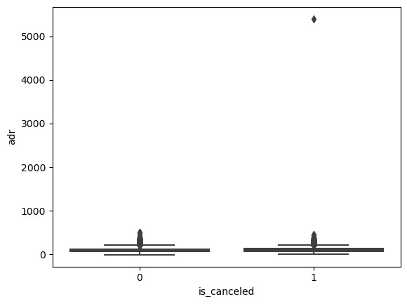

```python
sns.boxplot(x="is_canceled", y="adr", data=df)
```

```python
adr_deletmax=df[df["adr"]!=5400]
```

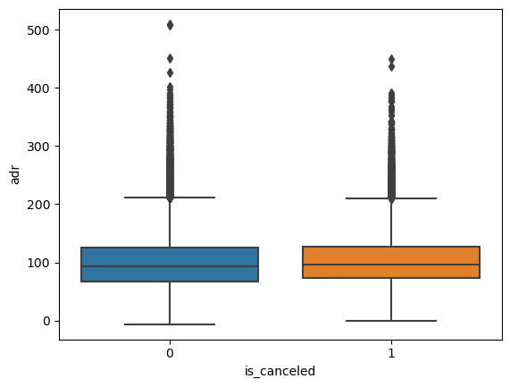

```python
sns.boxplot(x="is_canceled", y="adr", data=adr_deletmax)
```

## Descriptive Analysis

#### How many bookings and cancellations are there, and what patterns can be discerned?

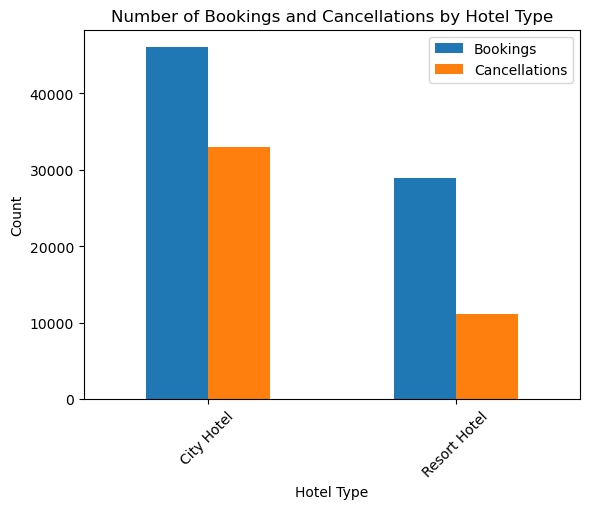

```python
# Counting the number of bookings and cancellations for each hotel type
booking_counts = df.groupby('hotel')['is_canceled'].value_counts().unstack()

# Creating a bar plot
plt.figure(figsize=(10, 6))
ax = booking_counts.plot(kind='bar', stacked=False, rot=0)
ax.set_xticklabels(booking_counts.index, rotation=45)
plt.title('Number of Bookings and Cancellations by Hotel Type')
plt.xlabel('Hotel Type')
plt.ylabel('Count')
plt.legend(['Bookings', 'Cancellations'])
plt.show()
```

```python
booking_counts
```

| is_canceled hotel | 0 | 1 |
| --- | --- | --- |
| City Hotel | 46046 | 32996 |
| Resort Hotel | 28888 | 11108 |

It can be seen that there are more reservations at the City Hotel than at the Resort Hotel. This might be because of many things, including location, price, desire, and supply. Also, both types of hotels have cancellations, but the City Hotel has a lot more than the Resort Hotel. This might be a sign of a trend where hotel reservations in cities are more unstable or open to change.The ratio of cancellations to bookings at the City Hotel is about 0.72, which means that for every ticket, there's a good chance that it will be canceled.

With about 0.38 cancellations per booking, the Resort Hotel has a lower percentage. This could mean that reservations at resort hotels are more likely to be kept than reservations at city hotels.Based on the data, City Hotels' high number of cancellations could mean that they need to be more flexible with booking rules or come up with a better way to overbook rooms to make up for lost revenue. Even though there are fewer cancellations at resort hotels, they still need to think about how these affect their occupancy rates and might benefit from marketing tactics that aim to reduce cancellations.

#### What is the distribution of hotel bookings across different months?

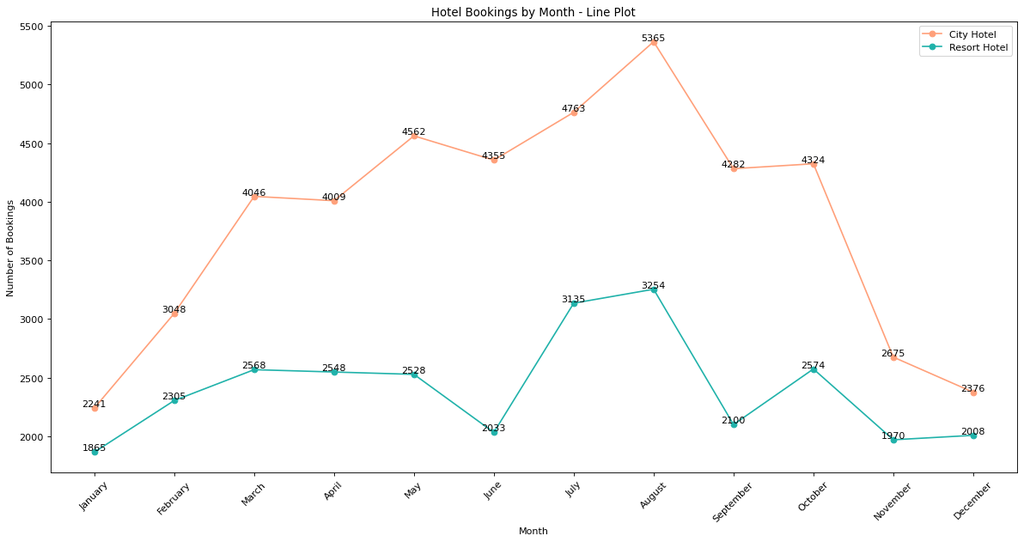

```python
# Defining the months as they were not previously defined in the code snippet provided by the user
months = ['January', 'February', 'March', 'April', 'May', 'June',
          'July', 'August', 'September', 'October', 'November', 'December']

# Filtering out non-canceled bookings for each hotel type
city_hotel = df[(df['hotel'] == 'City Hotel') & (df['is_canceled'] == 0)]
resort_hotel = df[(df['hotel'] == 'Resort Hotel') & (df['is_canceled'] == 0)]

# Resetting index for both DataFrames
city_hotel.reset_index(drop=True, inplace=True)
resort_hotel.reset_index(drop=True, inplace=True)

# Getting the monthly booking counts for each hotel type
city_month = city_hotel['arrival_date_month'].value_counts().reindex(months)
resort_month = resort_hotel['arrival_date_month'].value_counts().reindex(months)

# Now plotting the line plot with all the necessary elements including the months
plt.figure(figsize=(15,8), dpi=80)
plt.plot(months, city_month.values, marker='o', label='City Hotel', color='lightsalmon')
plt.plot(months, resort_month.values, marker='o', label='Resort Hotel', color='lightseagreen')
plt.xticks(rotation=45)
plt.legend()
plt.xlabel('Month')
plt.ylabel('Number of Bookings')
plt.title('Hotel Bookings by Month - Line Plot')

# Adding data labels
for x_val, y_val in zip(months, city_month.values):
    plt.text(x_val, y_val + 0.1, f'{int(y_val)}', ha='center', va='bottom')

for x_val, y_val in zip(months, resort_month.values):
    plt.text(x_val, y_val + 0.1, f'{int(y_val)}', ha='center', va='bottom')

plt.tight_layout()
plt.show()
```

As of March, the number of reservations for the City Hotel has been slowly going up, hitting a high point of 5,365 in August. This rise is because it's the busiest time of year for city trips, which is usually summer. This is an interesting fact: in January, only 2,241 people book rooms at the City Hotel. After that, the number of people keeps going up. Things change a lot when summer is over. The number of reservations at the City Hotel dropped sharply in September and didn't go up again until the end of the year.

From what has been seen, it looks like the seasons change both places, with faster times in the summer and less busy times later in the year. All year, more people book rooms at the City Hotel than at the Resort Hotel. This could mean that people are always looking for places to stay in cities instead of at the Resort Hotel, which is more for vacations.

#### What is the relationship between guests' countries of origin and their booking cancellation rates?

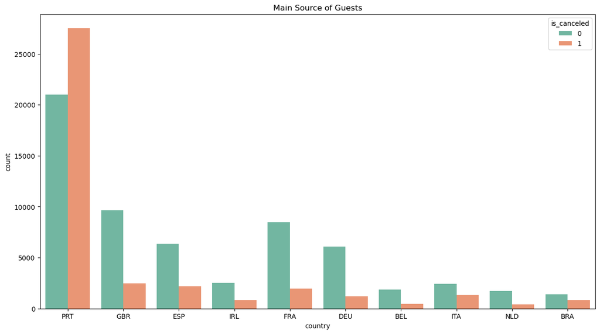

```python
country_book=df['country'].value_counts()[:10]
country_cancel=df[(df.country.isin (country_book.index)) & (df.is_canceled==1)]['country'].value_counts()
plt.figure(figsize=(15,8))
sns.countplot(x='country'
              ,data=df[df.country.isin (country_book.index)]
              ,hue='is_canceled'
              ,palette=sns.color_palette('Set2',2)
             )
plt.title('Main Source of Guests')
```

```python
country_book
```

```
country
PRT    48483
GBR    12120
FRA    10401
ESP     8560
DEU     7285
ITA     3761
IRL     3374
BEL     2342
BRA     2222
NLD     2103
Name: count, dtype: int64
```

```python
country_cancel
```

```
country
PRT    27506
GBR     2452
ESP     2177
FRA     1933
ITA     1333
DEU     1218
IRL      832
BRA      830
BEL      474
NLD      387
Name: count, dtype: int64
```

Guest cancellation rates by country are shown in the bar chart. The bar chart and data show international guest booking and cancellation tendencies.

Portugal (PRT) guests lead in bookings and cancellations with 48,483 and 27,506 respectively. This shows that Portuguese guests cancel over half of their bookings. British visitors (GBR) had 12,120 bookings and 2,452 cancellations. France (FRA) and Spain (ESP) guests have 10,401 and 8,560 bookings, respectively, and 1,933 and 2,177 cancellations.

The top countries' lowest booking numbers are 2,342, 2,103, and 2,222 for Belgian (BEL), Dutch (NLD), and Brazilian (BRA) guests. The Netherlands had 387 cancellations, Belgium 474, and Brazil 830, following the lower trend. Brazil had a higher cancellation rate.

According to the patterns, both areas are busier in summer and less crowded later in the year. The City Hotel has more reservations year-round, suggesting that customers prefer city hotels to resort hotels.

#### What are the different customer segments based on their booking behaviors?

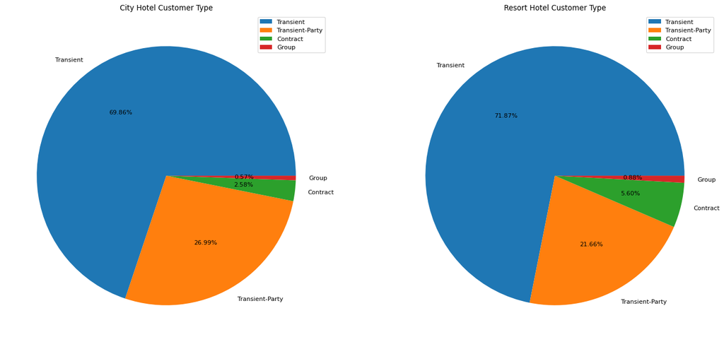

```python
city_customer=city_hotel.customer_type.value_counts()
resort_customer=resort_hotel.customer_type.value_counts()
plt.figure(figsize=(21,12),dpi=80)
plt.subplot(1,2,1)
plt.pie(city_customer,labels=city_customer.index,autopct='%.2f%%')
plt.legend(loc=1)
plt.title('City Hotel Customer Type')
plt.subplot(1,2,2)
plt.pie(resort_customer,labels=resort_customer.index,autopct='%.2f%%')
plt.title('Resort Hotel Customer Type')
plt.legend()
plt.show()
```

The pie charts compare City and Resort Hotel booking trends by client segment. The Transient segment accounts for the majority of customers at both City Hotel (69.86%) and Resort Hotel (71.87%), indicating that most guests book short-term stays for leisure or business travel.

#### How do cancellation rates differ between new and returning guests?

```
 [Text(0, 0, 'no'), Text(1, 0, 'yes')])
```

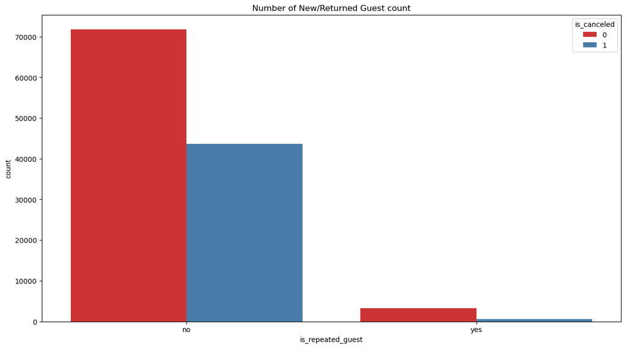

```python
plt.figure(figsize=(15,8))
sns.countplot(x='is_repeated_guest'
              ,data=df
              ,hue='is_canceled'
              ,palette='Set1'
             )
plt.title('Number of New/Returned Guest count')
plt.xticks(range(2),['no','yes'])
```

```python
guest_counts = df.groupby(['is_repeated_guest', 'is_canceled']).size().reset_index(name='count')

guest_counts
```

|  | is_repeated_guest | is_canceled | count |
| --- | --- | --- | --- |
| 0 | 0 | 0 | 71806 |
| 1 | 0 | 1 | 43649 |
| 2 | 1 | 0 | 3205 |
| 3 | 1 | 1 | 550 |

The bar chart shows new and repeat visitor cancelation rates. New hotel guests ('no') have more authorized bookings ('0') and cancellations ('1') than returning guests. New guests account for 71,806 bookings and 43,649 cancellations, showing that many new guests keep their appointments.

Returning guests have a far greater non-cancellation rate, with 3,205 staying and 550 canceling. While new guests are more frequent, repeat guests are more likely to keep their bookings, according to the research. Repeat guests are less likely to cancel, therefore guest loyalty is important.

### How do different deposit methods impact cancellation rates?

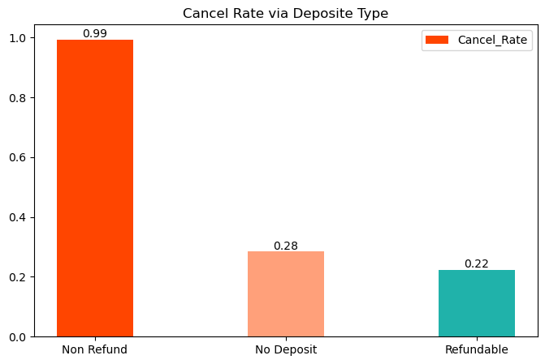

```python
deposit_cancel=(df.loc[df['is_canceled']==1]['deposit_type'].value_counts()/df['deposit_type'].value_counts()).sort_values(ascending=False)
plt.figure(figsize=(8,5))
x=range(len(deposit_cancel.index))
y=deposit_cancel.values
plt.bar(x,y,label='Cancel_Rate',color=['orangered','lightsalmon','lightseagreen'],width=0.4)
plt.xticks(x,deposit_cancel.index)
plt.legend()
plt.title('Cancel Rate via Deposite Type')
for x,y in zip(x,y):
    plt.text(x,y,'%.2f' % y,ha = 'center',va = 'bottom')
```

The highest cancellation rate is for non-refundable deposits, roughly 1 (or 99%), suggesting that guests will almost certainly cancel. This is paradoxical as a non-refundable deposit should discourage cancellations. However, guests may have to pay a non-refundable deposit just for high-demand periods or special rates where they are more likely to cancel, or the statistics may be incorrect.

No-deposit bookings have a 0.28 (28%) cancellation rate. Lack of upfront financial commitment may not increase cancellation rates compared to non-refundable deposits.

Given that guests are less likely to cancel if they may get their deposit back, the refundable deposit type has the lowest cancellation rate of 0.22 (22%).

The data suggests that cancellation rules and deposit types influence booking cancellations. This information could help hotel management structure deposit requirements to balance cancellation risk with non-refundable deposit revenue.

## Model Development and Evaluation

```python
from sklearn.model_selection import train_test_split, KFold, cross_validate, cross_val_score
from sklearn.pipeline import Pipeline
from sklearn.compose import ColumnTransformer
from sklearn.preprocessing import LabelEncoder, OneHotEncoder
from sklearn.impute import SimpleImputer
from sklearn.ensemble import RandomForestClassifier
from sklearn.metrics import accuracy_score
from sklearn.model_selection import train_test_split
from sklearn.pipeline import Pipeline
from sklearn.ensemble import RandomForestClassifier
from sklearn.metrics import classification_report
import eli5 # Feature importance evaluation
```

```python
# Select columns to include, excluding some to make the model more general and to prevent leakage
# (arrival_date_year, assigned_room_type, booking_changes, reservation_status, country, days_in_waiting_list)

num_features = ["lead_time", "arrival_date_week_number", "arrival_date_day_of_month",
                "stays_in_weekend_nights", "stays_in_week_nights", "adults", "children",
                "babies", "is_repeated_guest", "previous_cancellations",
                "previous_bookings_not_canceled", "agent", "company",
                "required_car_parking_spaces", "total_of_special_requests", "adr"]

cat_features = ["hotel", "arrival_date_month", "meal", "market_segment",
                "distribution_channel", "reserved_room_type", "deposit_type", "customer_type"]

# Separate features and target value
features = num_features + cat_features
X = df.drop(["is_canceled"], axis=1)[features]
y = df["is_canceled"]

# Preprocess numerical features: fill missing values with 0
num_transformer = SimpleImputer(strategy="constant")

# Preprocess categorical features: fill missing values with "Unknown" and apply one-hot encoding
cat_transformer = Pipeline(steps=[
    ("imputer", SimpleImputer(strategy="constant", fill_value="Unknown")),
    ("onehot", OneHotEncoder(handle_unknown='ignore'))])

# Bundle preprocessing for numerical and categorical features
preprocessor = ColumnTransformer(transformers=[("num", num_transformer, num_features),
                                               ("cat", cat_transformer, cat_features)])
```

```python
# Split the dataset into training and testing sets
X_train, X_test, y_train, y_test = train_test_split(X, y, test_size=0.2, random_state=42)

# Create a Random Forest model
rf_model = RandomForestClassifier(random_state=42)

# Create a pipeline that includes preprocessing and model fitting
pipeline = Pipeline(steps=[('preprocessor', preprocessor),
                           ('classifier', rf_model)])

# Fit the model using the training data
pipeline.fit(X_train, y_train)

# Make predictions using the testing data
y_pred = pipeline.predict(X_test)

# Print the classification report
report = classification_report(y_test, y_pred)
print(report)
```

```
              precision    recall  f1-score   support

           0       0.87      0.93      0.90     14958
           1       0.87      0.76      0.81      8884

    accuracy                           0.87     23842
   macro avg       0.87      0.85      0.86     23842
weighted avg       0.87      0.87      0.87     23842
```

```python
from sklearn.tree import DecisionTreeClassifier

X_train, X_test, y_train, y_test = train_test_split(X, y, test_size=0.2, random_state=42)
# Create a Decision Tree model
dt_model = DecisionTreeClassifier(random_state=42)

# Create a pipeline that includes preprocessing and model fitting
pipeline = Pipeline(steps=[('preprocessor', preprocessor),
                           ('classifier', dt_model)])

# Fit the model using the training data
pipeline.fit(X_train, y_train)

# Make predictions using the testing data
y_pred = pipeline.predict(X_test)

# Print the classification report
report = classification_report(y_test, y_pred)
print(report)
```

```
              precision    recall  f1-score   support

           0       0.86      0.86      0.86     14958
           1       0.77      0.77      0.77      8884

    accuracy                           0.83     23842
   macro avg       0.81      0.81      0.81     23842
weighted avg       0.83      0.83      0.83     23842
```

Once the model is fitted with training data and deployed on the test set, the classification report gives a complete performance evaluation. The 87% accuracy indicates strong model correctness. Both classes (not canceled '0' and canceled '1') have 87% precision, demonstrating that the model can recognize true positives for both events. Class '0' has a 93% recall, suggesting the model is good at identifying actual non-cancellations. For class '1', the recall is 76%, indicating that all genuine cancellations can be identified better.

The model predicts non-cancellations better than cancellations, since the F1-score balances precision and recall at 90% for non-cancellations and 81% for cancellations.

Hotel management benefits greatly from this paradigm. The hotel can better manage inventory, enhance revenue management, and offer dynamic pricing or overbooking to cover cancellation costs by reliably anticipating cancellations.

### Feature Importance

Understanding which features most strongly influence the outcome can improve predictive modeling decision-making. The following statistics and graph demonstrate the importance of features for hotel booking cancelation models.

```python
from sklearn.tree import DecisionTreeClassifier
import eli5

# Preprocess the data
X_preprocessed = preprocessor.fit_transform(X)

# Train the decision tree model
dt_model = DecisionTreeClassifier(random_state=42)
dt_model.fit(X_preprocessed, y)

# Get one-hot encoded feature names
onehot_columns = list(preprocessor.named_transformers_['cat'].
                      named_steps['onehot'].
                      get_feature_names(input_features=cat_features))

# Combine numerical features and one-hot encoded categorical features
feat_imp_list = num_features + onehot_columns

# Show the 10 most important features with their names
feat_imp_df = eli5.formatters.as_dataframe.explain_weights_df(
    dt_model,
    feature_names=feat_imp_list)
feat_imp_df.head(10)
```

|  | feature | weight |
| --- | --- | --- |
| 0 | deposit_type_Non Refund | 0.238431 |
| 1 | lead_time | 0.151761 |
| 2 | adr | 0.099035 |
| 3 | arrival_date_day_of_month | 0.070155 |
| 4 | total_of_special_requests | 0.055487 |
| 5 | arrival_date_week_number | 0.052485 |
| 6 | agent | 0.046341 |
| 7 | stays_in_week_nights | 0.039738 |
| 8 | market_segment_Online TA | 0.039380 |
| 9 | previous_cancellations | 0.032779 |

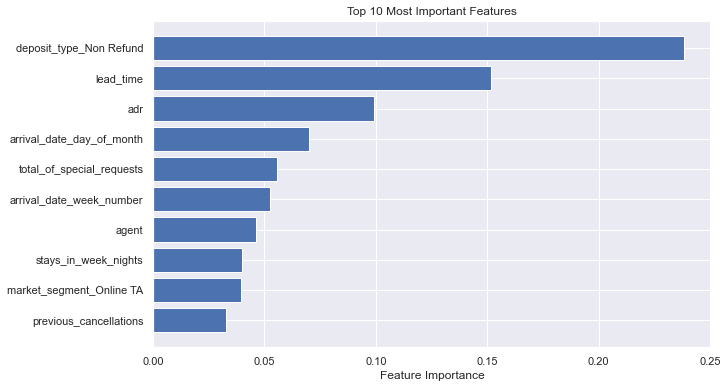

```python
import matplotlib.pyplot as plt

# Get the top 10 most important features
top_feat_imp_df = feat_imp_df.head(10)

# Plot the feature importances
plt.figure(figsize=(10, 6))
plt.barh(top_feat_imp_df['feature'], top_feat_imp_df['weight'], align='center')
plt.xlabel('Feature Importance')
plt.title('Top 10 Most Important Features')
plt.gca().invert_yaxis()  # Invert the y-axis to show the most important feature at the top
plt.show()
```

## Conclusion

This research suggests various areas for future exploration and improvement. More hotel booking data from diverse geographies, types of hotels, and time periods can help us understand patterns and customer behavior. Feature engineering, model optimization, and hyperparameter tuning can improve model accuracy and predictions. Hotels may understand what consumers want and how satisfied they are with their services and products by combining customer evaluations and comments with sentiment analysis. These analytics can help hotels design targeted marketing programs and employ dynamic pricing to adjust room rates based on demand, seasonality, and other factors. More reservations, happier customers, and improved revenue management and occupancy will result.

This study illuminated the factors that effect hotel reservations and cancellations and illustrated how data-driven decisions could improve the hotel industry. Knowing these things helps hotel managers make better judgments, adapt marketing programs, and run their businesses more efficiently to satisfy client expectations and do a better job.

## References

- Li, X., Wang, D., Liang, X., Huang, Z., & Su, Z. (2018). The impact of online user-generated content on hotel room sales: A data-driven approach. International Journal of Contemporary Hospitality Management, 30(10), 3199-3217.
- Provost, F., & Fawcett, T. (2013). Data science for business: What you need to know about data mining and data-analytic thinking. O'Reilly Media, Inc.